# Simulation of Exponential Distribution using R

Carlos Hernández

25/9/2020

```r
set.seed(1)
library(ggplot2)
theme_set(theme_bw())
```

## Overview

In this project we will investigate the exponential distribution in R and compare it with the Central Limit Theorem. The exponential distribution can be simulated in R with rexp(n, lambda) where lambda is the rate parameter. The mean of exponential distribution is 1/lambda and the standard deviation is also 1/lambda.

To achieve this we will investigate the distribution of averages of 40 exponentials with lambda 0.2, replicated a thousand times.

```r
lambda <- 0.2
n <- 40
```

## Definitions

#### Exponential Distribution

The exponential distribution describes the arrival time of a randomly recurring independent event sequence. If μ is the mean waiting time for the next event recurrence, its probability density function is:

$$\begin{equation}
\nonumber f_X(x) = \left\{
\begin{array}{l l}
\lambda e^{-\lambda x} & \quad x > 0\\
0 & \quad \textrm{otherwise}
\end{array} \right.
\end{equation}$$

Here is a graph of the exponential distribution with mean = 1.

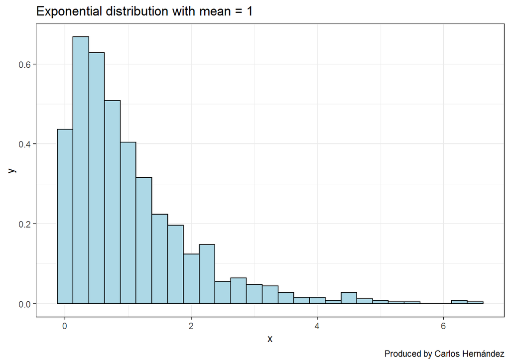

```r
data <- data.frame(value = c(t(rexp(1000, rate = 1))))

ggplot(data, aes(x=value)) +
  geom_histogram(aes(y=..density..),binwidth=.25, col="black", fill="lightblue")+
    labs(title= "Exponential distribution with mean = 1", caption="Produced by Carlos Hernández") +
   xlab("x") +
  ylab("y")
```

#### Central Limit Theorem

The central limit theorem states that if you have a population with mean μ and standard deviation σ and take sufficiently large random samples from the population, then the distribution of the sample means will be approximately normally distributed.

This will hold true regardless of whether the source population is normal or skewed, provided the sample size is sufficiently large (usually n > 30). If the population is normal, then the theorem holds true even for samples smaller than 30. In fact, this also holds true even if the population is binomial, provided that min(np, n(1-p))> 5, where n is the sample size and p is the probability of success in the population. This means that we can use the normal probability model to quantify uncertainty when making inferences about a population mean based on the sample mean.

## Simulation

First we are going to simulate our exponential distribution, and replicated it one thousand times.

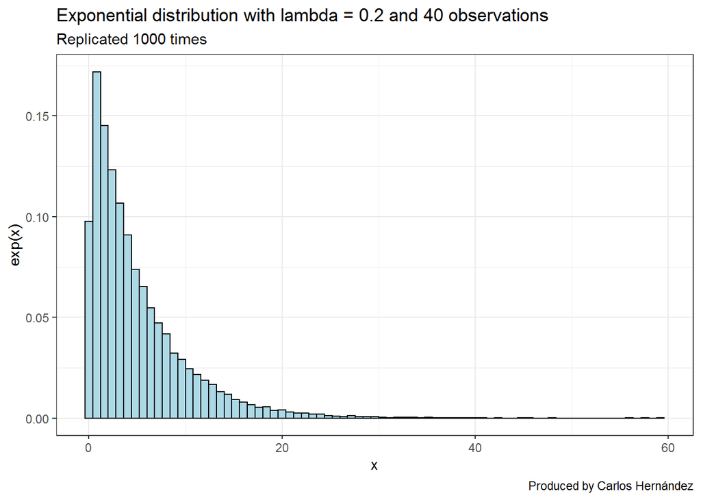

```r
expData <- replicate(1000, rexp(n, lambda)) # replicate 1000 times
expData <- data.frame(value = c(t(expData))) # convert to data frame

# plot
ggplot(expData, aes(x=value)) +
  geom_histogram(aes(y=..density..), binwidth=.8,colour="black", fill="lightblue") +
   labs(title= "Exponential distribution with lambda = 0.2 and 40 observations", subtitle = "Replicated 1000 times", caption="Produced by Carlos Hernández") +
  xlab("x") +
  ylab("exp(x)")
```

According to the Central Limit Theorem, if we take simple random samples from the population and compute the mean for each of the samples, the distribution of sample means should be approximately normal.

Thus, we can calculate the mean of the distribution one thousand times and save its value in a data frame and the resulted distribution should be approximately normal.

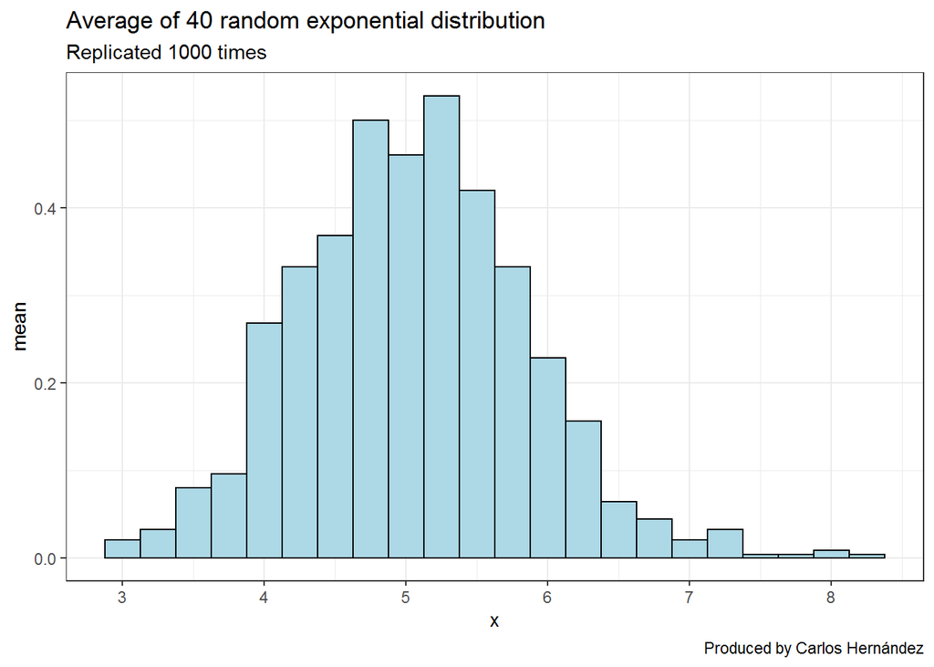

```r
data <- replicate(1000, mean(rexp(n,lambda)))
data <- data.frame(value = c(t(data)), size = 40)

ggplot(data, aes(x=value)) +
  geom_histogram(aes(y=..density..),binwidth=.25, col="black", fill="lightblue") +
  labs(title= "Average of 40 random exponential distribution", subtitle = "Replicated 1000 times", caption="Produced by Carlos Hernández") +
  xlab("x") +
  ylab("mean")
```

## Sample Mean versus Theoretical Mean

We know that the theoretical mean is given by 1/lambda, so we can calculate it and compare it with the sample mean.

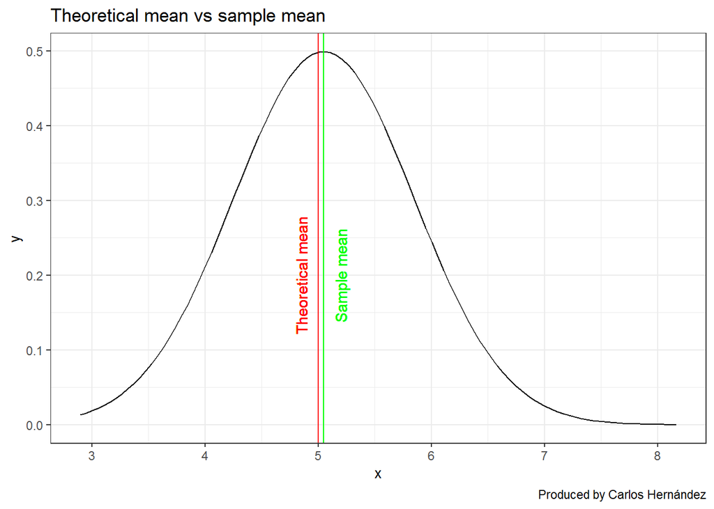

```r
theoretical_mu <- 1/lambda # calculate theoretical mean
sample_mu <-mean(data$value) # calculate experimental mean

ggplot(data, aes(x=value)) +
  stat_function(fun=dnorm,
                         color="black",
                         args=list(mean=mean(data$value),
                                  sd=sd(data$value)))+
  geom_vline(xintercept = theoretical_mu, colour="red") +
  geom_text(aes(x=theoretical_mu-.25, label="\nTheoretical mean", y=.2), colour="red", angle=90, text=element_text(size=11)) +
  geom_vline(xintercept = sample_mu, colour="green")+
  geom_text(aes(x=sample_mu+.05, label="\nSample mean", y=.2), colour="green", angle=90, text=element_text(size=11)) +
  labs(title= "Theoretical mean vs sample mean", caption="Produced by Carlos Hernández") +
  xlab("x") +
  ylab("y")
```

The theoretical mean is: 5 and the sample mean is: 5.05.

## Sample Variance versus Theoretical Variance

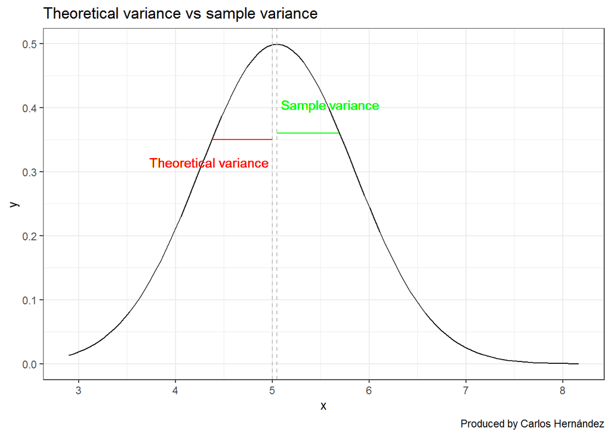

```r
theoretical_variance <- 1/(n * lambda^2)
sample_variance <- round(var(data$value),3)

ggplot(data, aes(x=value)) +
  stat_function(fun=dnorm,
                         color="black",
                         args=list(mean=mean(data$value),
                                  sd=sd(data$value)))+
  geom_vline(xintercept = sample_mu, colour="gray", linetype="dashed")+
  geom_vline(xintercept = theoretical_mu, colour="gray", linetype="dashed")+
  geom_segment(aes(x = sample_mu, y = 0.36, xend =sample_mu + sample_variance, yend = 0.36), colour="green") +
  geom_segment(aes(x = theoretical_mu - theoretical_variance, y = 0.35, xend =theoretical_mu, yend = 0.35), colour="red") +
  labs(title= "Theoretical variance vs sample variance", caption="Produced by Carlos Hernández") +
  geom_text(aes(x=sample_mu+.55, label="\nSample variance", y=.42), colour="green") +
  geom_text(aes(x=theoretical_mu-.65, label="\nTheoretical variance", y=.33), colour="red") +
  xlab("x") +
  ylab("y")
```

The theoretical variance is: 0.625 and the sample variance is: 0.638.

## Distribution: the distribution is approximately normal

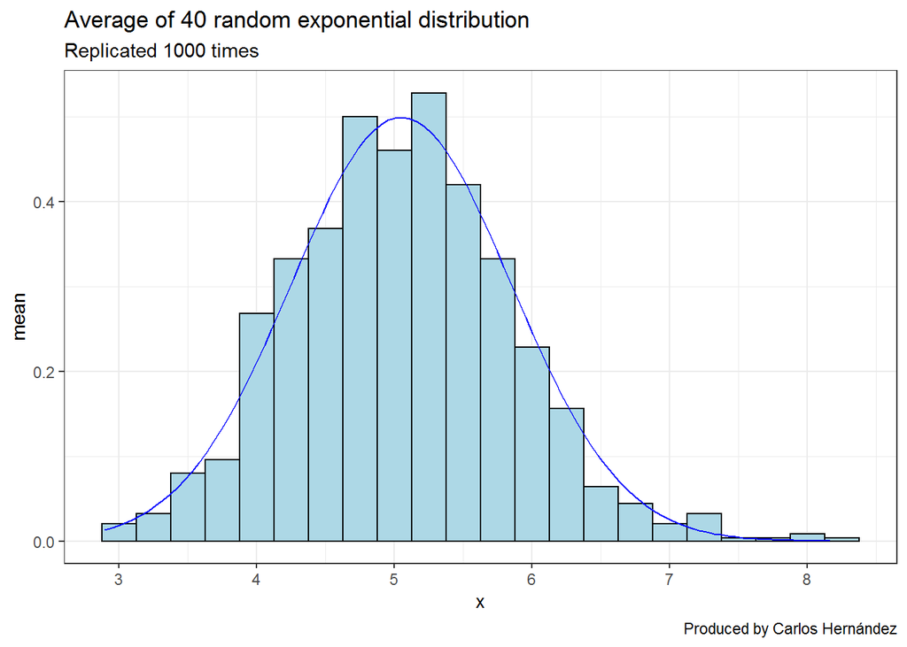

```r
ggplot(data, aes(x=value)) +
  geom_histogram(aes(y=..density..),binwidth=.25, col="black", fill="lightblue") +
  stat_function(fun=dnorm,
                         color="blue",
                         args=list(mean=mean(data$value),
                                  sd=sd(data$value)))+
  labs(title= "Average of 40 random exponential distribution", subtitle = "Replicated 1000 times", caption="Produced by Carlos Hernández") +
  xlab("x") +
  ylab("mean")
```